# Mapping COVID Mask Usage in R

Brad Stieber

8/1/2020

The coronavirus pandemic is still not under control [across the United States](https://www.nytimes.com/interactive/2020/us/coronavirus-us-cases.html). One of the [easiest ways](http://files.fast.ai/papers/masks_lit_review.pdf) to [protect you and those around you](https://www.washingtonpost.com/business/2020/06/17/masks-salons-missouri/) is by [wearing a mask](http://ftp.iza.org/dp13319.pdf) when [you leave the house](https://www.healthaffairs.org/doi/10.1377/hlthaff.2020.00818). The New York Times performed a [survey](https://www.nytimes.com/interactive/2020/07/17/upshot/coronavirus-face-mask-map.html) to investigate mask usage across the US. In this post, I’m going to explore that data a bit, and then end with a cautionary tale of calculating percentages with a small sample.

I originally found a [data visualization on Reddit](https://www.reddit.com/r/dataisbeautiful/comments/i047e9/oc_countylevel_map_of_maskusage_in_the_united/) which used the data to create the following map:

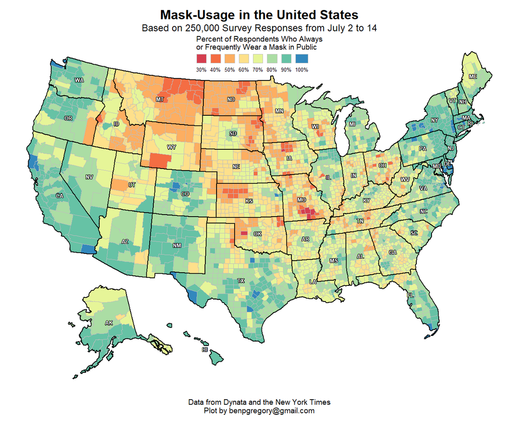

So I decided to try and extend the analysis, similar to another [blog post](https://bgstieber.github.io/post/iterating-on-a-2016-election-analysis/) I wrote about the 2016 election.

## The Data

In a separate [script](https://github.com/bgstieber/files_for_blog/blob/master/covid-mask-map/getdata.R), I’ve collected [the data](https://github.com/bgstieber/files_for_blog/raw/master/covid-mask-map/covid19_model_data.csv) we’ll need for this analysis. The data comes from a variety of sources: the [NYtimes survey](https://github.com/nytimes/covid-19-data/raw/master/mask-use/mask-use-by-county.csv), [covid data](https://usafacts.org/visualizations/coronavirus-covid-19-spread-map/), [2016 election results](https://github.com/tonmcg/US_County_Level_Election_Results_08-16/raw/master/2016_US_County_Level_Presidential_Results.csv), and [the census](https://walker-data.com/tidycensus/index.html).

```r
head(covid_data)
```

```
## # A tibble: 6 x 12
##   COUNTYFP fips_numeric county_name freq_always deaths_per_100K deaths_per_cases
##   <chr>           <dbl> <chr>             <dbl>           <dbl>            <dbl>
## 1 01001            1001 Autauga Co~       0.739           21.5           0.0217
## 2 01003            1003 Baldwin Co~       0.759            4.48          0.0142
## 3 01005            1005 Barbour Co~       0.692            4.05          0.00306
## 4 01007            1007 Bibb County       0.85             4.47          0.00571
## 5 01009            1009 Blount Cou~       0.653            1.73          0.00457
## 6 01011            1011 Bullock Co~       0.786           99.0           0.0272
## # ... with 6 more variables: trump_ratio_clinton <dbl>, inc <dbl>,
## #   edu_pct <dbl>, population_density <dbl>, females_65_plus_pct <dbl>,
## #   state_abbr <chr>
```

Here are the columns in that data:

- **COUNTYFP**, **fips_numeric**, **county_name**: county-level data
- **freq_always**: % "frequently or always wear a mask in public when you expect to be within six feet of another person
- **deaths_per_100K**: as of July 1st, # of covid-19 deaths per 100K people in the county
- **deaths_per_cases**: as of July 1st, # of covid-19 deaths per covid-19 cases in the county
- **trump_ratio_clinton**: the ratio of Trump’s percentage vote to Clinton’s ($\%Trump/\%Cllinton$)
- **inc**: per capita income in the county
- **edu_pct**: % of county with a bachelor’s or higher
- **population_density**: population density of the county (people per square mile)
- **females_65_plus_pct**: % of the female population aged 65 or older in the county
- **state_abbr**: state code

Obviously, to recreate the map above, all we need to know is the county and % of people wearing a mask frequently or always. I brought in a few extra columns which will be used later on in the analysis.

## Let’s Make a Map

In the map above, the creator used a [diverging color palette](http://www.personal.psu.edu/cab38/ColorSch/SchHTMLs/CBColorDiv.html). Typically, a diverging palette will be used when there is a “central point” in the data set. For example, if you were comparing how a stock price has changed from the previous year, the central point of the data would be 0.

To improve on the map from above, we can instead use a [sequential color palette](http://www.personal.psu.edu/cab38/ColorSch/SchHTMLs/CBColorSeq.html). A sequential color palette does not require the data to have a midpoint, instead it just reflects a data series that goes from low to high.

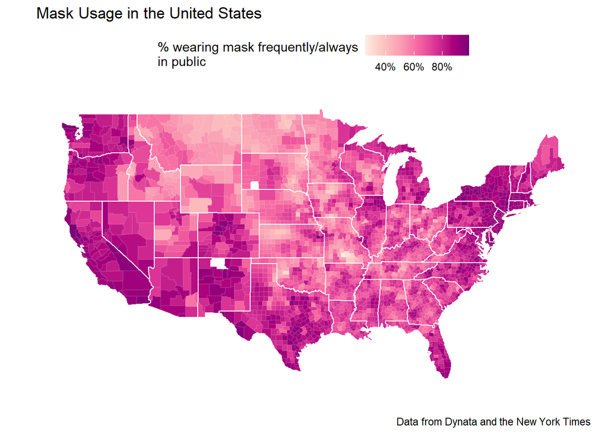

## Calculating Percentages with a Small Sample

```r
experiment <- replicate(10000, expr = c("n10" = mean(rbinom(10, 1, .5)),
                                        "n100" = mean(rbinom(100, 1, .5)),
                                        "n1000" = mean(rbinom(1000, 1, .5))))

experiment_df <- as_tibble(t(experiment))
```

An interesting quirk of this data is the relationship between the population of a county and the % of respondents frequently or always wearing a mask.